# Handling the peculiarities of marine movement data

### 4.1.2 Handling data gaps

There are several ways to deal with data gaps:

1. Split tracks
2. Interpolate locations
3. Fill the gaps with NAs
4. Multiple imputation

The method to use will depend on the main analysis you are interested in.

### 4.1.3 Splitting tracks

One way to account for missing data is to split the track where there are large gaps (i.e., assign each track segment a new individual ID). This strategy is particularly appropriate when you have long enough gaps for which interpolation method are unlikely to perform well. We can split the tracks when the gaps larger than a predetermined threshold.

Here, we will use a function (found in `utility_functions.R`) to split the tracks. We define the maximum allowable gap (at which point it will start a new segment), as well as the shortest allowable track segment.

These are somewhat arbitrary decisions, and depend on your subsequent choices for regularisation. In this tutorial, we will be interpolating missing locations (within each segment) and so we only want to allow gaps that can reasonably be predicted.

We are using a 30 min resolution, so we allow a 90 minute gap (i.e., we assume we can predict 2 missing locations), and we want each segment to be at least 120 min (i.e., have at least 5 locations) long so that we have enough information about state transitions.

```r
# Use function from utility_function.R to split data at gaps
track_split <- split_at_gap(data = tracks_gps_O,
                           max_gap = 90,
                           shortest_track = 120)
```

The new data has an updated `ID` column, where with the original ID and track segment number. The original ID is now in `ID_old`

```r
head(track_split)
```

```
##          ID                time        x       y loc_class dt  ID_old
## 1 T172062-1 2017-08-08 00:20:00 -80.6525 72.2728       GPS 22 T172062
## 2 T172062-1 2017-08-08 00:42:00 -80.6665 72.2719       GPS 10 T172062
## 3 T172062-1 2017-08-08 00:52:00 -80.6692 72.2674       GPS 17 T172062
## 4 T172062-1 2017-08-08 01:09:00 -80.6682 72.2582       GPS 10 T172062
## 5 T172062-1 2017-08-08 01:19:00 -80.6613 72.2574       GPS 10 T172062
## 6 T172062-1 2017-08-08 01:29:00 -80.6592 72.2563       GPS 15 T172062
```

This data is still irregular, but now we have smaller segments split when there are large data gaps. Let’s visualize the different segment.

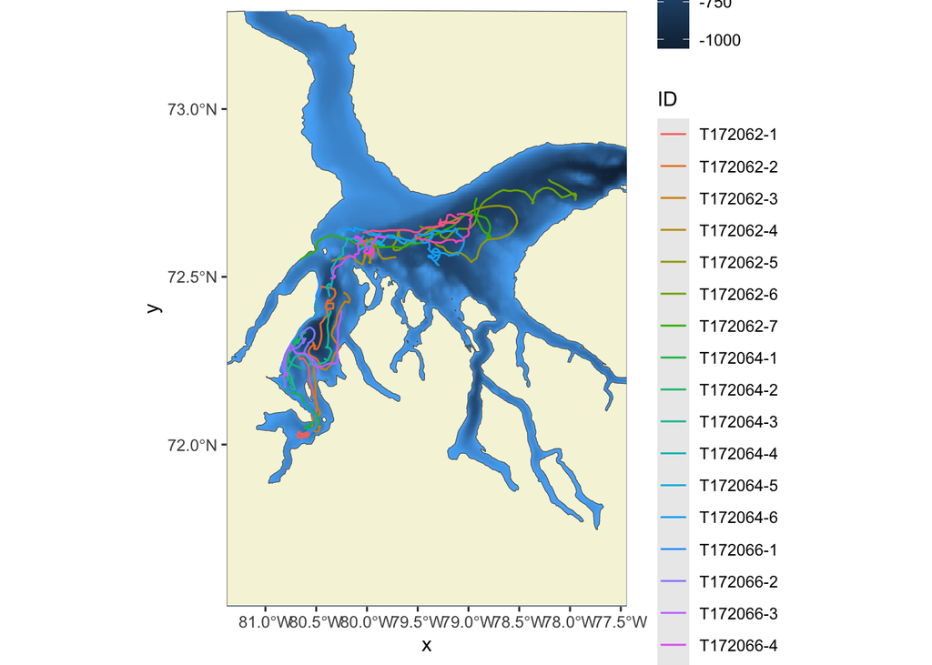

```r
ggplot() +
  geom_spatraster(data = bathy) +
  geom_sf(data = land, fill = "beige") +
  geom_spatial_path(data = track_split,
                    aes(x = x, y = y, colour = ID), crs = 4326) +
  coord_sf(expand = FALSE)
```

Splitting the tracks is often be a first step, before interpolating or other adjustments.

### 4.1.4 Interpolation (correlated random walk)

Once the track is split, there is often still irregularity within each segments, and we want to interpolate or predict new locations to form a regular grid of observations.

The simplest approach is to use linear interpolation between missing times, but a better option is to predict locations from a continuous-time correlated random walk (CTCRW). `momentuHMM` contains wrapper functions to interpolate missing locations by fitting a CTCRW to the data based on the `crawl` package by Devin Johnson and Josh London. There are many options to fit the CTCRW model, and a detailed tutorial for analysis with `crawl` is available here: https://jmlondon.github.io/crawl-workshop/crawl-practical.html. Let’s try to fit the most basic model using the wrapper function `crawlWrap`. In the most basic form, we only need to provide tracking data with the columns `ID`, `time`, `x`, and `y` and specify the desired temporal resolution.

First, let us transform the data into an `sf` object. `crawlWrap` can also take a data.frame as an argument but that would imply renaming some of our columns. It is easier to just transform the data into an `sf` object.

Here it’s important to project the data in a good coordinate system, since the model takes into account speed/step length.

```r
track_split_sf <- track_split %>%
  st_as_sf(coords = c("x", "y")) %>% # converts to an sf object
  st_set_crs(4326) %>% # define CRS
  st_transform(2962) # reproject data to a UTM
```

Now we can fit the CTCRW to each track segment and create a data frame of predicted locations. We decided above that a good, maybe conservative time interval was 30 min. We will use that interval here. Since interpolating when they are large data gaps can bias our analysis, we use the split tracks.

The default model fitted is the simplest model. For example, it does not include the drift component described in Johnson et al. (2008) and we have not included covariates in the movement or error equations.

```r
# crawl can fail to fit periodically, so I recommend always setting a seed
set.seed(12)

# fit crawl
crwOut <- crawlWrap(obsData = track_split_sf, timeStep = "30 mins", theta = c(7, 0))
## Fitting 20 track(s) using crawl::crwMLE...
## Individual T172062-1...
## Individual T172062-2...
## Individual T172062-3...
## Individual T172062-4...
## Individual T172062-5...
## Individual T172062-6...
## Individual T172062-7...
## Individual T172064-1...
## Individual T172064-2...
## Individual T172064-3...
## Individual T172064-4...
## Individual T172064-5...
## Individual T172064-6...
## Individual T172066-1...
## Individual T172066-2...
## Individual T172066-3...
## Individual T172066-4...
## Individual T172066-5...
## Individual T172066-6...
## Individual T172066-7...
## DONE
##
## Predicting locations (and uncertainty) at 30 mins time steps for 20 track(s) using crawl::crwPredict...
## DONE
```

Let’s look at the output of the model for the first track.

```r
crwOut$crwFits$`T172062-1`
```

```
##
##
## Continuous-Time Correlated Random Walk fit
##
## Models:
## --------
## Movement   ~ 1
## Error
##
##
##                      Parameter Est. St. Err. 95% Lower 95% Upper
## ln sigma (Intercept)          8.098    0.224     7.659     8.536
## ln beta (Intercept)           0.106    0.250    -0.385     0.597
##
##
## Log Likelihood = -883.048
## AIC = 1770.095
```

```r
exp(crwOut$crwFits$`T172062-1`$estPar)
```

```
## [1] 3286.450264    1.111567
```

We get the log likelihood value, the AIC value, and the estimated parameters. Here, the autocorrelation parameter, $\hat{\beta}$, is 1.11 and the variability parameter, $\hat{\sigma}$, is 3286.

The autocorrelation parameter represent how quickly the temporal correlation in velocity tends towards 0. According to Johnson et al (2008), if the time difference between two time steps is $\Delta = 3/\beta$, then the velocities are roughly independent. Here, this would be achieved in the following time (in hour):

```r
3/exp(crwOut$crwFits$`T172062-1`$estPar)[2]
```

```
## [1] 2.698893
```

Let’s look at a few track segments with interpolated values.

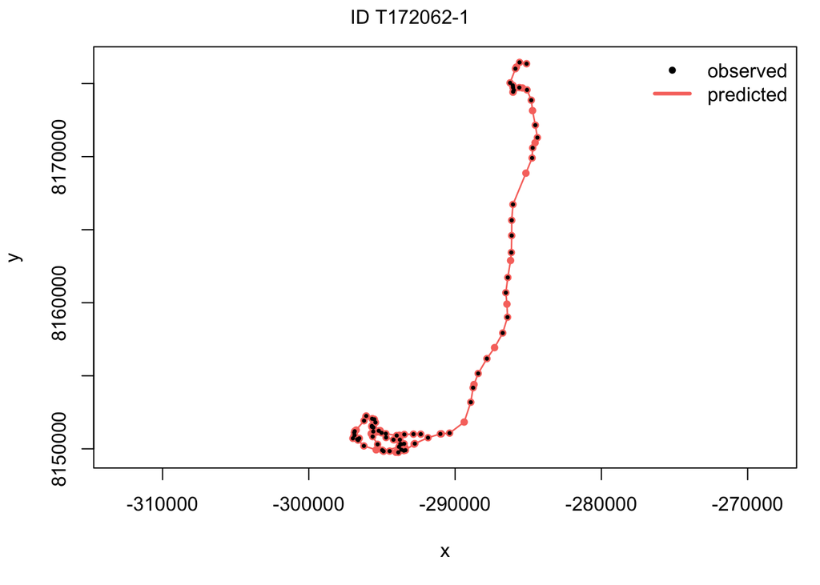

```r
plot(crwOut, animals = "T172062-1", ask = FALSE)
```

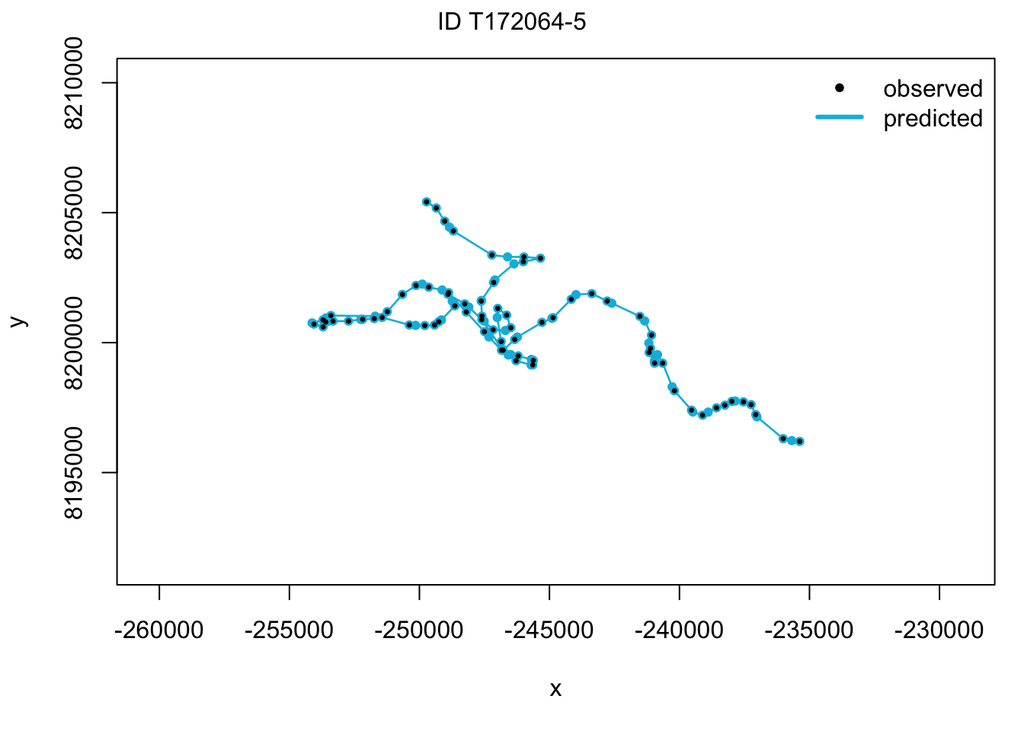

```r
plot(crwOut, animals = "T172064-5", ask = FALSE)
```

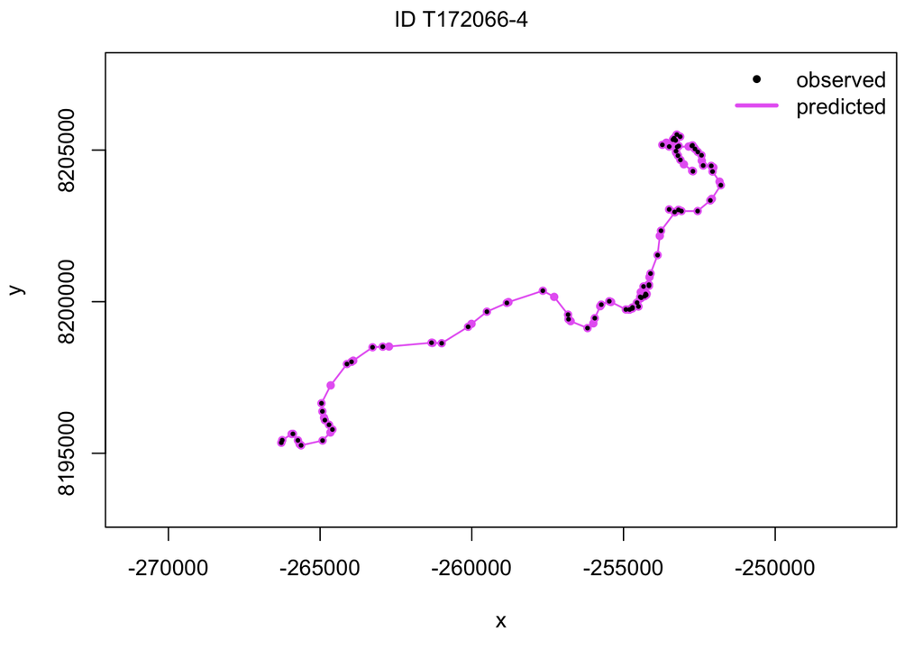

```r
plot(crwOut, animals = "T172066-4", ask = FALSE)
```

Notice how the predicted tracks do not make perfectly straight lines through missing sections, which is an improvement on what a simple linear interpolation method would provide.

We can now extract the predicted regular tracks.

```r
# Get predicted tracks from crawl output
track_int <- crwOut$crwPredict[which(crwOut$crwPredict$locType == "p"),
                              c( "ID", "mu.x", "mu.y", "time")]
colnames(track_int) <- c( "ID","x", "y", "time")
head(track_int)
##           ID         x       y                time
## 1  T172062-1 -285113.8 8176359 2017-08-08 00:20:00
## 4  T172062-1 -285813.8 8176130 2017-08-08 00:50:00
## 8  T172062-1 -286046.5 8174867 2017-08-08 01:20:00
## 11 T172062-1 -286045.6 8174408 2017-08-08 01:50:00
## 14 T172062-1 -285394.1 8174699 2017-08-08 02:20:00
## 17 T172062-1 -284706.5 8173150 2017-08-08 02:50:00
```

Note here that the time is at every 30 min.

### 4.1.5 Place NAs in (small) gaps

Instead of interpolating, one can leave data gaps as NAs. Some analysis, for example hidden Markov models without spatial covariates extracted from the locations, could easily handle NAs in the locations. The maximum size of a gap to allow depends on the frequency of the missing data, frequency of locations, study species, and behaviours of interest. However, for many analyses that assume regular time interval, it’s important to explicitly include the NAs, so that the function knows that there are missing data they have to account for. Placing NAs for missing locations can be used on its own or in conjunction with splitting tracks. The package `adehabitatLR` has a function `setNA` dedicated to it.

We will apply this to the split tracks that we used previously used in the tutorial. Here, instead of using crawl to interpolate missing locations, we are simply creating a dataframe with the missing locations set to NA (i.e., creating a regular grid of observations with some NAs). The idea is that we still want to separate tracks into segment when there are large data gaps, but place NAs when it’s just a few locations missing.

The first step is to create an adhabitat trajectory. Here, we simply input coordinates, time, and the ID (here track segment id).

```r
track_ltraj <- as.ltraj(xy = track_split[, c("x", "y")],
                                   date = track_split$time,
                                   id = track_split$ID)
```

Now we set the NAs. As before, we use a time interval of 30 min. We specify that we have a tolerance for the imprecision in the data, here at most 15 min. We use the first location at the time reference.

```r
# Create adehabitat object, containing the trajectory padded with NAs
track_NA <- setNA(ltraj = track_ltraj,
                  date.ref = track_split$time[1],
                  dt = 30, tol = 15, units = "min")

# Transform back to dataframe
track_NA <- ld(track_NA)[, c("id", "x", "y", "date")]
colnames(track_NA) <- c("ID", "x", "y", "time")
head(track_NA, 20)
```

```
##           ID        x       y                time
## 1  T172062-1 -80.6525 72.2728 2017-08-08 00:20:00
## 2  T172062-1 -80.6692 72.2674 2017-08-08 00:52:00
## 3  T172062-1 -80.6592 72.2563 2017-08-08 01:29:00
## 4  T172062-1 -80.6558 72.2550 2017-08-08 02:04:00
## 5  T172062-1 -80.6316 72.2582 2017-08-08 02:26:00
## 6  T172062-1 -80.5892 72.2403 2017-08-08 03:02:00
## 7  T172062-1 -80.5767 72.2269 2017-08-08 03:25:00
## 8  T172062-1 -80.5700 72.2211 2017-08-08 03:36:00
## 9  T172062-1 -80.5483 72.1727 2017-08-08 04:31:00
## 10 T172062-1 -80.5235 72.1482 2017-08-08 05:02:00
## 11 T172062-1 -80.4939 72.1258 2017-08-08 05:29:00
## 12 T172062-1 -80.5002 72.0977 2017-08-08 06:00:00
## 13 T172062-1 -80.4967 72.0694 2017-08-08 06:32:00
## 14 T172062-1       NA      NA 2017-08-08 06:50:00
## 15 T172062-1 -80.5478 72.0395 2017-08-08 07:34:00
## 16 T172062-1 -80.5795 72.0272 2017-08-08 08:04:00
## 17 T172062-1 -80.6075 72.0230 2017-08-08 08:30:00
## 18 T172062-1 -80.6217 72.0218 2017-08-08 08:40:00
## 19 T172062-1 -80.6583 72.0199 2017-08-08 09:20:00
## 20 T172062-1 -80.6724 72.0231 2017-08-08 09:57:00
```

We can see now that there are NAs for some locations, and that the time is not exactly at every 30 min, but close to. So this may not be adequate for some analysis that require strict time regularity. One could round to the nearest 30min, but this could be problematic.

You could alternatively use `amt` to split the tracks into “burst” (i.e., segment) and regularize at the same time.

```r
tracks_gps_30 <- tracks_gps_amt %>% nest(data = -"id") %>%
  mutate(steps = map(data, function(x)
    x %>% track_resample(rate = minutes(30), tolerance = minutes(5))))
tracks_gps_30 <- tracks_gps_30 %>% unnest(steps)
head(tracks_gps_30, 20)
```

```
## # A tibble: 20 × 6
##    id      data                    x_    y_ t_                  burst_
##  * <fct>   <list>               <dbl> <dbl> <dttm>               <dbl>
##  1 T172064 <trck_xyt [488 × 3]> -80.5  72.5 2017-08-08 00:00:00      1
##  2 T172064 <trck_xyt [488 × 3]> -80.5  72.4 2017-08-08 00:32:00      1
##  3 T172064 <trck_xyt [488 × 3]> -80.5  72.4 2017-08-08 01:02:00      1
##  4 T172064 <trck_xyt [488 × 3]> -80.5  72.4 2017-08-08 01:31:00      1
##  5 T172064 <trck_xyt [488 × 3]> -80.5  72.5 2017-08-08 02:09:00      2
##  6 T172064 <trck_xyt [488 × 3]> -80.5  72.5 2017-08-08 02:40:00      2
##  7 T172064 <trck_xyt [488 × 3]> -80.5  72.5 2017-08-08 03:11:00      2
##  8 T172064 <trck_xyt [488 × 3]> -80.5  72.5 2017-08-08 04:00:00      3
##  9 T172064 <trck_xyt [488 × 3]> -80.5  72.4 2017-08-08 04:25:00      3
## 10 T172064 <trck_xyt [488 × 3]> -80.5  72.4 2017-08-08 05:00:00      3
## 11 T172064 <trck_xyt [488 × 3]> -80.5  72.4 2017-08-08 05:32:00      3
## 12 T172064 <trck_xyt [488 × 3]> -80.5  72.4 2017-08-08 06:00:00      3
## 13 T172064 <trck_xyt [488 × 3]> -80.6  72.4 2017-08-08 06:33:00      3
## 14 T172064 <trck_xyt [488 × 3]> -80.7  72.3 2017-08-08 07:00:00      3
## 15 T172064 <trck_xyt [488 × 3]> -80.7  72.3 2017-08-08 07:34:00      3
## 16 T172064 <trck_xyt [488 × 3]> -80.8  72.3 2017-08-08 08:01:00      3
## 17 T172064 <trck_xyt [488 × 3]> -80.8  72.3 2017-08-08 08:34:00      3
## 18 T172064 <trck_xyt [488 × 3]> -80.8  72.2 2017-08-08 09:03:00      3
## 19 T172064 <trck_xyt [488 × 3]> -80.8  72.2 2017-08-08 09:36:00      3
## 20 T172064 <trck_xyt [488 × 3]> -80.8  72.2 2017-08-08 10:02:00      3
```

YOu would then need to place NAs afterward.

### 4.1.6 Multiple Imputation

For many analyses where you need to extract covariates from the location data, it may be wise to use multiple imputation, where you create multiple tracks with a CTCRW model and extract the covariates for each of the tracks. Then you can propagate the uncertainty in other analyses.

Multiple imputation works by first fitting a CTCRW model to the original data, second, drawing (i.e., simulating) a number of realisations of the position process based on the CTCRW model, third (not done here), fitting your model of interest to each of the simulated realisations, and finally, pooling the estimated parameters. `momentuHMM` has several functions to implement multiple imputation. The function `MIfitHMM` can be used both to simulate realisations of a fitted CTCRW and fit hidden Markov model (HMMs) to each one. The number of simulations is specified with `nSims`. We can simulate realisations without fitting HMMs by setting `fit = FALSE`.

Here, let’s use first fit a CTCRW model on segmented tracks created above. We will simulate 4 tracks using MIfitHMM.

```r
set.seed(12)

# Fit the correlated random walk, MIfitHMM takes a crwData object
crw_gps_30 <- crawlWrap(obsData = track_split_sf, timeStep = "30 mins")
```

```
## Fitting 20 track(s) using crawl::crwMLE...
## Individual T172062-1...
```

```
## Individual T172062-2...
```

```
## Individual T172062-3...
```

```
## Individual T172062-4...
```

```
## Individual T172062-5...
```

```
## Individual T172062-6...
```

```
## Individual T172062-7...
```

```
## Individual T172064-1...
```

```
## Individual T172064-2...
```

```
## Individual T172064-3...
```

```
## Individual T172064-4...
```

```
## Individual T172064-5...
```

```
## Individual T172064-6...
```

```
## Individual T172066-1...
```

```
## Individual T172066-2...
```

```
## Individual T172066-3...
```

```
## Individual T172066-4...
```

```
## Individual T172066-5...
```

```
## Individual T172066-6...
```

```
## Individual T172066-7...
```

```
## DONE
```

[output not shown]

```
## DONE
```

```r
# simulate 4 realisations of the 30 min GPS CTCRW model
MI_sim_gps <- MIfitHMM(crw_gps_30, nSims = 4, fit = FALSE)
```

```
## Drawing 4 realizations from the position process using crawl...
```

```
## DONE
```

```
## DONE
```

This will return warning messages. They are not shown here, but one should look at the segments that resulted in warning messages. This can potentially be fixed by forcing longer track segments above.

Let’s look at one segment: `T172066-6`.

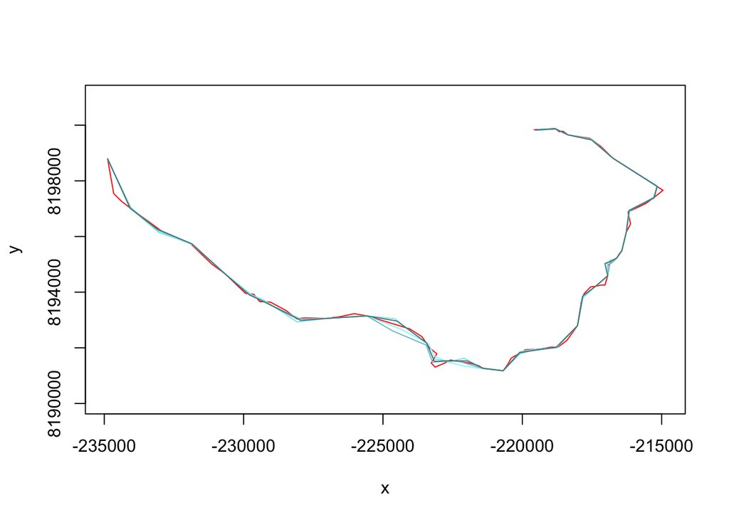

```r
ID_seg <- "T172066-6"
# plot locations for first narwhal
# filter first ID from original data
track_eg <- track_split_sf %>%
  mutate(x = st_coordinates(track_split_sf)[,"X"],
         y = st_coordinates(track_split_sf)[,"Y"]) %>%
  filter(ID == ID_seg)

# filter first ID for each simulation
sim_tracks <- lapply(MI_sim_gps$miData, function(x){
  filter(x, ID == ID_seg)})

# plot original track for first narwhal
plot(track_eg$x, track_eg$y, col = "red", xlab = "x", ylab = "y", asp = 1, type = "l")

# plot each simulated track
mute <- mapply(function(data, col) {
                 points(y ~ x, data = data, col = col, type = "l")
               }, data = sim_tracks,
               col = list("cadetblue1", "cadetblue2", "cadetblue3", "cadetblue4"),
               SIMPLIFY = FALSE)
```

Notice how in some areas the different simulations have generally good agreement in the likely location during gaps, while in others they diverge. Multiple imputation can be particularly powerful if we want to incorporate environmental variables, as spatially explicit variables can be extracted for each simulated track to sample the most likely conditions encountered by the animal.